# Pilot Experiment 1: Learnability

## Needed functions

Create dataframes for compehension tests and write-in data.

```r
analyze<- function(datas) {
  dataTesting <-list()
  scores <- c()
  for (i in 1:length(datas)) {
    dataTesting[[i]] <- datas[[i]][datas[[i]]$trialType == "testing",]
    dataTesting[[i]]$correct = dataTesting[[i]]$correctChoiceNumber == dataTesting[[i]]$participantChoiceNumber
  }
  return(dataTesting)
}

analyzeMeanTesting <- function(dataTesting) {
  dataTestingLevel <- list()
  for (i in 1:length(dataTesting)) {
    dataTestingLevel[[i]] <- dataTesting[[i]] %>%
      group_by(level)  %>%
      summarize(level_score = sum(correct)/length(correct))
    dataTestingLevel[[i]]$condition <- rep(dataTesting[[i]]$condition[1], 3)
    dataTestingLevel[[i]]$conditionCE <- rep(dataTesting[[i]]$conditionCE[1], 3)
    dataTestingLevel[[i]]$conditionHeadN <- rep(dataTesting[[i]]$conditionHeadN[1], 3)
    dataTestingLevel[[i]]$user <- rep(dataTesting[[i]]$workerId[1], 3)
  }
  dataTestingLevelAllUsers <- rbind()
  for (dat in dataTestingLevel) {
    dataTestingLevelAllUsers <- rbind(dataTestingLevelAllUsers, dat)
  }
  return(dataTestingLevelAllUsers)
}


analyzeWritingMeans<- function (data_write) {
  data_write_level <- list()
  for (j in 1:length(data_write)) {
    data_write_level[[j]] <- data_write[[j]] %>% group_by(level) %>% summarize(meanC = mean(correctness))
    data_write_level[[j]]$condition <- rep(data_write[[j]]$condition[1], 4)
    data_write_level[[j]]$conditionCE <- rep(data_write[[j]]$conditionCE[1], 4)
    data_write_level[[j]]$conditionHeadN <- rep(data_write[[j]]$conditionHeadN[1], 4)
    data_write_level[[j]]$user<- rep(data_write[[j]]$workerId[1], 4)
  }

  data_write_levelAll <- rbind()
  for (d in data_write_level) {
    data_write_levelAll <- rbind(data_write_levelAll, d)
  }
  return (data_write_levelAll)
}
```

## Processing the data

Import task data and demographic files, which have been anonymized.

```r
setwd("/Users/emilydavis/Desktop/paper data/pilotExperLearnability")
dataAnon <- read.csv(paste0(getwd(), '/allDataAnonPilot.csv'))
prepList <- read.csv(paste0(getwd(), '/prepListPilot.csv'))
dataAnon$conditionCE[dataAnon$conditionCE == "no center-embedding"] <- "branching"
dataFiles <- split(dataAnon, dataAnon$workerId)
allDataWriteMerged <- dataAnon[dataAnon$trialType == "write",]
allDataTesting <- analyze(dataFiles)
allDataTestingMerged <- rbind()
for (dat in allDataTesting) {
  allDataTestingMerged <- rbind(allDataTestingMerged, dat)
}
allDataTestingLevel <- analyzeMeanTesting(allDataTesting)
allDataTestingMean <- allDataTestingLevel %>% group_by(conditionCE, conditionHeadN, level) %>% summarize(level_score = mean(level_score))
```

## Comprehension

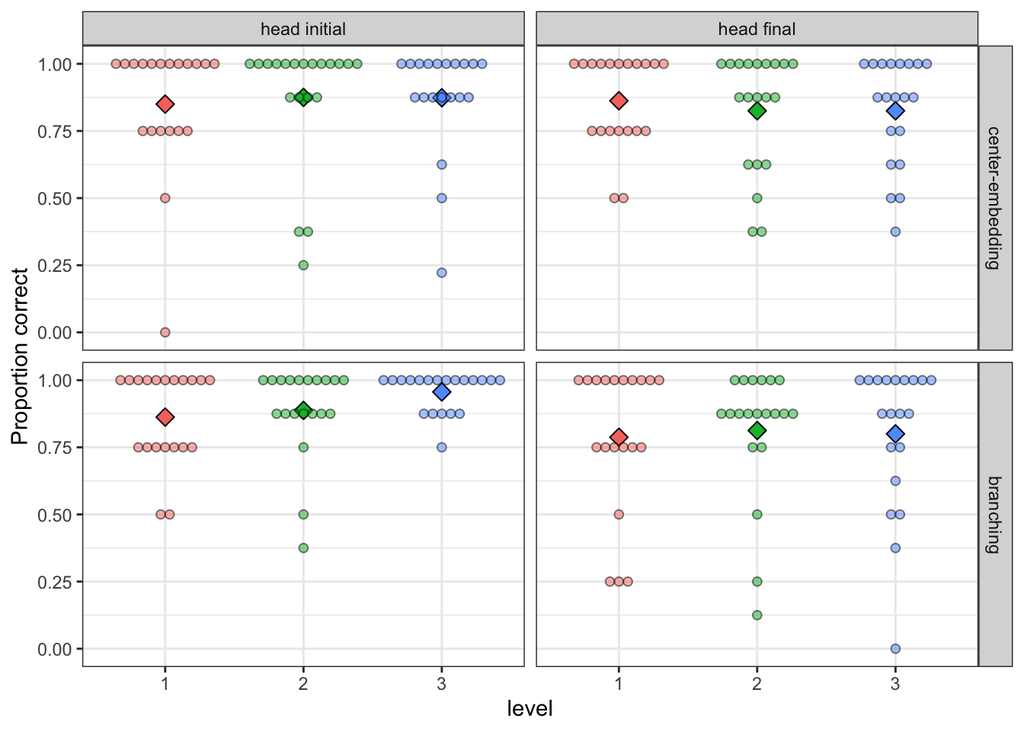

```r
allDataTestingLevel$level <- as.factor(allDataTestingLevel$level)
allDataTestingLevel$conditionHeadN <- as.factor(allDataTestingLevel$conditionHeadN)
allDataTestingLevel$conditionCE <- as.factor(allDataTestingLevel$conditionCE)
allDataTestingLevel$conditionHeadN <- relevel(allDataTestingLevel$conditionHeadN, "head initial", "head final")
allDataTestingLevel$conditionCE <- relevel(allDataTestingLevel$conditionCE, "center-embedding")
ggplot(allDataTestingLevel, aes(x= level, y= level_score, fill = level))+
  stat_summary(aes(fill = level,group=1), fun= "mean", geom="point", pch = 23, size = 3) +
  geom_dotplot(binaxis='y',stackdir='center', alpha = .5)+
  facet_grid(conditionCE ~ conditionHeadN)+
  scale_x_discrete(name = "level", labels = c("1", "2", "3"))+
  scale_fill_discrete(guide=FALSE)+
  ylab("Proportion correct")+
   theme_bw()
```

Mixed effects model of correct-answer rates on comprehension tests by level.

```r
allDataTestingMerged$level <- as.factor(allDataTestingMerged$level)
allDataTestingMerged$conditionHeadN <- as.factor(allDataTestingMerged$conditionHeadN)
allDataTestingMerged$conditionCE <- as.factor(allDataTestingMerged$conditionCE)
contrasts(allDataTestingMerged$conditionCE) <- contr.sum(2)
contrasts(allDataTestingMerged$conditionHeadN) <- contr.sum(2)
contrasts(allDataTestingMerged$level) <- contr.sdif(3)
testLmerInteract <- glmer(correct ~ level* conditionCE * conditionHeadN + (1 +level|workerId), data = allDataTestingMerged, family = "binomial")
```

# Write-in accuracy

(This stage is simplified a lot in the subsequent experiments)

First create a lexicon for each user, consisting of the correct versions of the nouns and prepositions.

```r
correctLexicon <- c()
for (worker in unique(allDataWriteMerged$workerId)) {
  workerTrials <- nrow(allDataWriteMerged[allDataWriteMerged$workerId == worker,])
  nouns <- as.character(allDataWriteMerged[allDataWriteMerged$workerId == worker,]$compositionalAnswer[1:4])
  participantCorrects <- paste(c(nouns, "rae", "moy"), collapse = " ")
  correctLexicon <- c(correctLexicon, rep(participantCorrects, workerTrials))
}
allDataWriteMerged <- cbind(allDataWriteMerged, correctLexicon)
allDataWriteMerged$correctLexicon <- as.character(allDataWriteMerged$correctLexicon)
allDataWriteMerged$participantText <- as.character(allDataWriteMerged$participantText)
allDataWriteMerged$participantText[is.na(allDataWriteMerged$participantText)] <- ' '
```

Correct user’s input so that each word becomes the closest (lowest normalized edit distance) word in the lexicon. If words are equidistant from two correct words, pick the first on the list. Unidentifiable words (too far in edit distance from any lexicon word) and a few known English words are notated as X.

```r
correctedAnswers <- c()
for (i in 1:nrow(allDataWriteMerged)) {
  #remove extra spaces
  entry <- gsub("\\s+", " ", str_trim(allDataWriteMerged$participantText[i]))
  split <- strsplit(entry, " ")[[1]]
  correctedWords <- c()
  for (word in split) {
    word = tolower(word)
    dists <- c()
    corrects <- strsplit(allDataWriteMerged$correctLexicon[i], " ")[[1]]
    for (c in corrects) {
      ds <- stringdist(word, c, method = "osa")/max(nchar(word), nchar(c))
      dists <- c(dists, ds)
    }
    closest <- which(dists == min(dists))
    #if equidistant, choose one
    english = c("and", "aside")
    if (min(dists) > .75 || word %in% english) {
      correctedWords <- c(correctedWords, "X")
    } else {
    if (length(closest) > 1) {
      correctedWords <- c(correctedWords, corrects[closest[1]])
    } else {
    correctedWords <- c(correctedWords, corrects[closest])
    }
    }
  }
  cor <- paste(correctedWords, collapse = " ")
  correctedAnswers  <- c(correctedAnswers, cor)
}
allDataWriteMerged <- cbind(allDataWriteMerged, correctedAnswers)
```

Now encode the corrected and compositional columns as initials, and compare by OSA.

```r
encodingCompositional <- c()
encodingCorrected <- c()
for (i in 1:nrow(allDataWriteMerged)) {
  splitP <- strsplit(as.character(allDataWriteMerged$compositionalAnswer[i]), " ")[[1]]
  initialsP <- c()
  for (word in splitP) {
   initialsP <- c(initialsP, substring(word, 1, 1))
    }
  initP <- paste(initialsP, collapse = "")
  encodingCompositional <- c(encodingCompositional, initP)
}
allDataWriteMerged <- cbind(allDataWriteMerged, encodingCompositional)

for (i in 1:nrow(allDataWriteMerged)) {
  splitC <- strsplit(as.character(allDataWriteMerged$correctedAnswers[i]), " ")[[1]]
  initialsC <- c()
  for (word in splitC) {
    initialsC <- c(initialsC, substring(word, 1, 1))
  }
  initC <- paste(initialsC, collapse = "")
  encodingCorrected <- c(encodingCorrected, initC)
}
allDataWriteMerged <- cbind(allDataWriteMerged, encodingCorrected)
normedCorrectness <- c()
for (i in 1:nrow(allDataWriteMerged)) {
  longer = max(
nchar(as.character(allDataWriteMerged$encodingCompositional[i])), nchar(as.character(allDataWriteMerged$encodingCorrected[i])) )
  normedC <- 1- (stringdist(as.character(allDataWriteMerged$encodingCompositional[i]),
                            as.character(allDataWriteMerged$encodingCorrected[i]),
                                      method = "osa")/longer)

  normedCorrectness <- c(normedCorrectness, normedC)
}
allDataWriteMerged <- cbind(allDataWriteMerged, normedCorrectness)
```

Graph and analyze normed correctness:

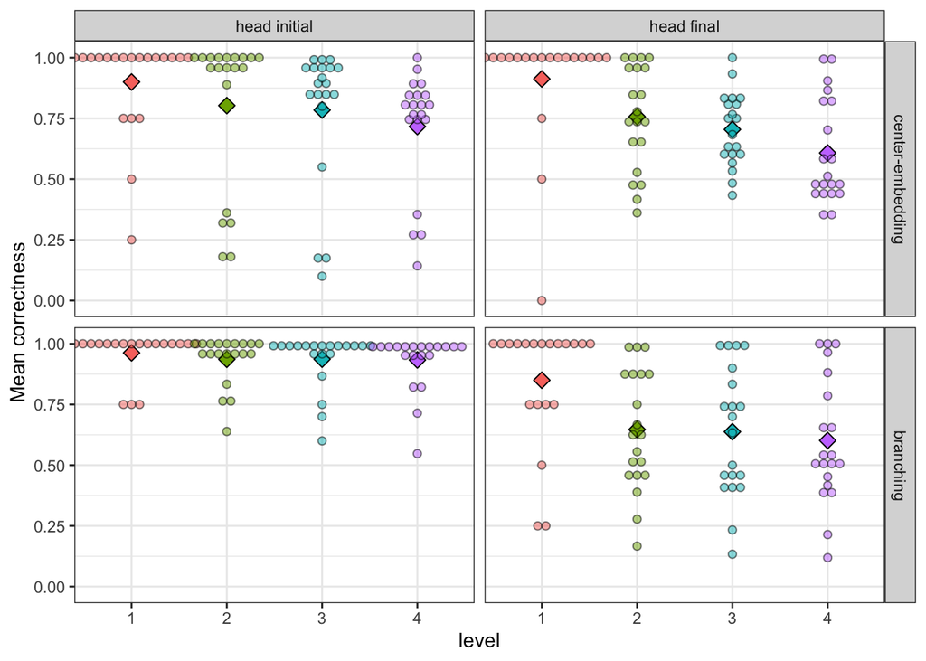

```r
allDataWriteMerged$conditionCE <- as.character(allDataWriteMerged$conditionCE)
allDataWriteMerged$conditionCE <- factor(allDataWriteMerged$conditionCE)
allDataWriteMerged$conditionHeadN <- as.character(allDataWriteMerged$conditionHeadN)
allDataWriteMerged$conditionHeadN <- factor(allDataWriteMerged$conditionHeadN)
analyzeWritingMeansN<- function (data_write, lev) {
  data_write_level <- list()
  for (j in 1:length(data_write)) {
    data_write_level[[j]] <- data_write[[j]] %>% group_by(level) %>% summarize(meanC = mean(normedCorrectness))
    data_write_level[[j]]$condition <- rep(data_write[[j]]$condition[1], lev)
    data_write_level[[j]]$conditionCE <- rep(data_write[[j]]$conditionCE[1], lev)
    data_write_level[[j]]$conditionHeadN <- rep(data_write[[j]]$conditionHeadN[1], lev)
    data_write_level[[j]]$user<- rep(data_write[[j]]$workerId[1], lev)
  }

  data_write_levelAll <- rbind()
  for (d in data_write_level) {
    data_write_levelAll <- rbind(data_write_levelAll, d)
  }
  return (data_write_levelAll)
}
writeList <- split(allDataWriteMerged, f = allDataWriteMerged$workerId)
allDataWriteMeansNormed <- analyzeWritingMeansN(writeList, 4)

allDataWriteMeansNormed$conditionHeadN <- relevel(allDataWriteMeansNormed$conditionHeadN, "head initial", "head final")
allDataWriteMeansNormed$conditionCE <- relevel(allDataWriteMeansNormed$conditionCE, "center-embedding")
allDataWriteMeansNormed$level <- as.factor(allDataWriteMeansNormed$level)
ggplot(allDataWriteMeansNormed, aes(x= level, y= meanC, fill = level))+
  stat_summary(aes(fill = level,group=1), fun= "mean", geom="point", pch = 23, size = 3) +
  geom_dotplot(binaxis='y',stackdir='center', alpha = .5)+
  facet_grid(conditionCE ~ conditionHeadN)+
  ylab("Mean correctness")+
  scale_fill_discrete(name = "level", labels = c("1", "2", "3", "4"))+
  scale_x_discrete(name = "level", labels = c("1", "2", "3", "4"))+
  theme_bw()+
  theme(legend.position = "none")
```

```r
contrasts(allDataWriteMerged$conditionCE) <- contr.sum(2)
contrasts(allDataWriteMerged$conditionHeadN) <- contr.sum(2)
allDataWriteMerged$level <- as.numeric(allDataWriteMerged$level)
writeLmerNormed <- lmer(normedCorrectness ~ as.numeric(level-1)* conditionCE * conditionHeadN + (1 +as.numeric(level-1)|workerId), data = allDataWriteMerged)
summary(writeLmerNormed)
```

```
## Linear mixed model fit by REML. t-tests use Satterthwaite's method [
## lmerModLmerTest]
## Formula:
## normedCorrectness ~ as.numeric(level - 1) * conditionCE * conditionHeadN +
##     (1 + as.numeric(level - 1) | workerId)
##    Data: allDataWriteMerged
##
## REML criterion at convergence: -1213.4
##
## Scaled residuals:
##     Min      1Q  Median      3Q     Max
## -4.9464 -0.3514  0.0742  0.4047  4.0895
##
## Random effects:
##  Groups   Name                  Variance Std.Dev. Corr
##  workerId (Intercept)           0.039594 0.19898
##           as.numeric(level - 1) 0.002431 0.04931  -0.01
##  Residual                       0.034667 0.18619
## Number of obs: 3194, groups:  workerId, 80
##
## Fixed effects:
##                                                     Estimate Std. Error
## (Intercept)                                         0.810844   0.022650
## as.numeric(level - 1)                              -0.050460   0.006456
## conditionCE1                                        0.008222   0.022650
## conditionHeadN1                                    -0.071799   0.022650
## as.numeric(level - 1):conditionCE1                  0.019661   0.006456
## as.numeric(level - 1):conditionHeadN1              -0.021590   0.006456
## conditionCE1:conditionHeadN1                       -0.051920   0.022650
## as.numeric(level - 1):conditionCE1:conditionHeadN1 -0.003238   0.006456
##                                                           df t value Pr(>|t|)
## (Intercept)                                        76.003343  35.800  < 2e-16
## as.numeric(level - 1)                              76.002740  -7.816 2.47e-11
## conditionCE1                                       76.003343   0.363  0.71760
## conditionHeadN1                                    76.003343  -3.170  0.00220
## as.numeric(level - 1):conditionCE1                 76.002740   3.045  0.00319
## as.numeric(level - 1):conditionHeadN1              76.002740  -3.344  0.00128
## conditionCE1:conditionHeadN1                       76.003343  -2.292  0.02466
## as.numeric(level - 1):conditionCE1:conditionHeadN1 76.002740  -0.502  0.61740
##
## (Intercept)                                        ***
## as.numeric(level - 1)                              ***
## conditionCE1
## conditionHeadN1                                    **
## as.numeric(level - 1):conditionCE1                 **
## as.numeric(level - 1):conditionHeadN1              **
## conditionCE1:conditionHeadN1                       *
## as.numeric(level - 1):conditionCE1:conditionHeadN1
## ---
## Signif. codes:  0 '***' 0.001 '**' 0.01 '*' 0.05 '.' 0.1 ' ' 1
##
## Correlation of Fixed Effects:
##             (Intr) as.(-1) cndCE1 cndHN1 as.(-1):CE1 a.(-1):H cCE1:H
## as.nmrc(-1) -0.072
## conditinCE1  0.000  0.000
## conditnHdN1  0.000  0.000   0.000
## as.(-1):CE1  0.000  0.000  -0.072  0.000
## as.(-1):HN1  0.000  0.000   0.000 -0.072  0.000
## cndtCE1:HN1  0.000  0.000   0.000  0.000  0.000       0.000
## a.(-1):CE1:  0.000  0.000   0.000  0.000  0.000       0.000   -0.072
```

## Seen vs. unseen arrays

“scales” is used to get a consistent and aesthetically pleasing color scheme shared across the different graphs.

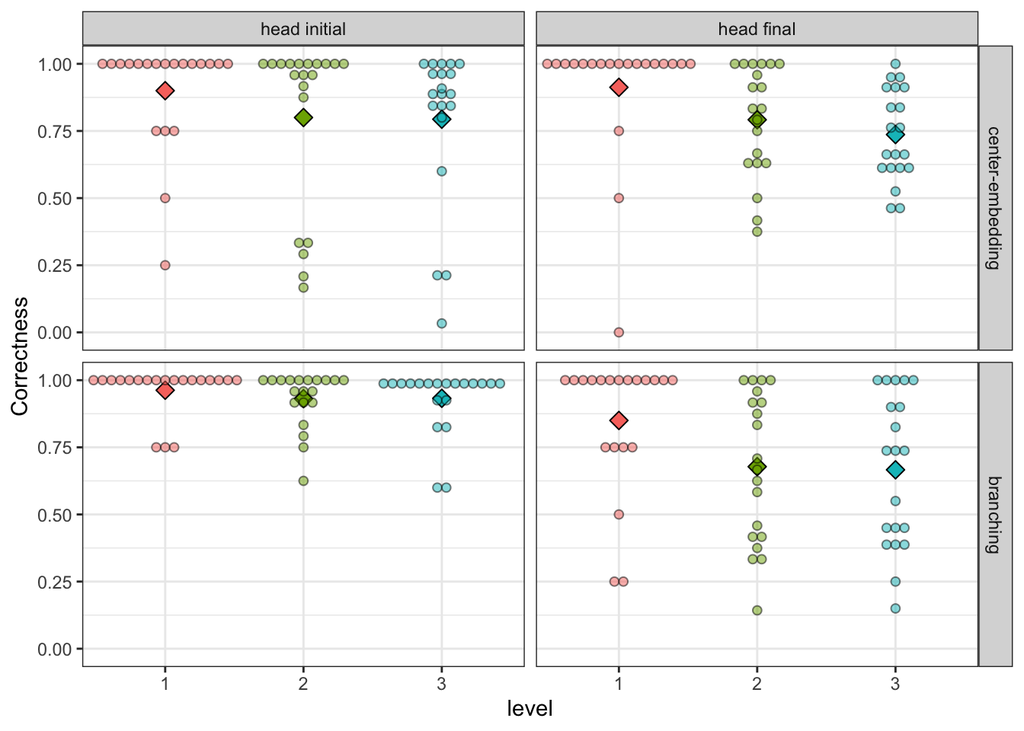

```r
library(scales)
colors <- hue_pal()(4)
adwmSeen <- allDataWriteMerged[allDataWriteMerged$seenInTesting == "true",]
adwmSeen$level <- as.factor(adwmSeen$level)
writeListSeen <- split(adwmSeen, f = adwmSeen$workerId)
allDataWriteMeansNormedSeen <- analyzeWritingMeansN(writeListSeen, 3)
allDataWriteMeansNormedSeen$conditionHeadN <- relevel(allDataWriteMeansNormedSeen$conditionHeadN, "head initial", "head final")
allDataWriteMeansNormedSeen$conditionCE <- relevel(allDataWriteMeansNormedSeen$conditionCE, "center-embedding")
allDataWriteMeansNormedSeen$level <- as.factor(allDataWriteMeansNormedSeen$level)
ggplot(allDataWriteMeansNormedSeen, aes(x= level, y= meanC, fill = level))+
  facet_grid(conditionCE ~ conditionHeadN)+
  scale_x_discrete(name = "level", labels = c("1", "2", "3"))+
  stat_summary(aes(fill = level,group=1), fun= "mean", geom="point", pch = 23, size = 3) +
  geom_dotplot(binaxis='y',stackdir='center', alpha = .5)+
  ylab("Correctness")+
  scale_fill_manual(values = colors[1:3] , labels = c("1", "2", "3"))+
  theme_bw()+
  theme(legend.position = "none")
```

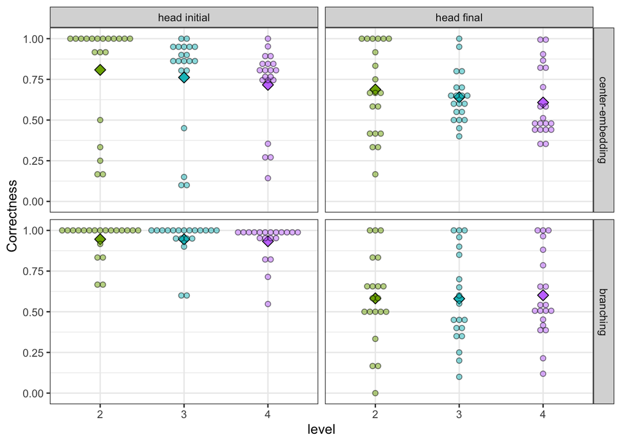

```r
adwmUnSeen <- allDataWriteMerged[allDataWriteMerged$seenInTraining == "false",]
adwmUnSeen$level <- as.factor(adwmUnSeen$level)
writeListUnSeen <- split(adwmUnSeen, f = adwmUnSeen$workerId)
allDataWriteMeansNormedUnSeen <- analyzeWritingMeansN(writeListUnSeen, 3)
allDataWriteMeansNormedUnSeen$conditionHeadN <- relevel(allDataWriteMeansNormedUnSeen$conditionHeadN, "head initial", "head final")
allDataWriteMeansNormedUnSeen$conditionCE <- relevel(allDataWriteMeansNormedUnSeen$conditionCE, "center-embedding")
allDataWriteMeansNormedUnSeen$level <- as.factor(allDataWriteMeansNormedUnSeen$level)
ggplot(allDataWriteMeansNormedUnSeen, aes(x= level, y= meanC, fill = level)) +
  facet_grid(conditionCE ~ conditionHeadN)+
  scale_x_discrete(name = "level", labels = c("2", "3", "4"))+
  stat_summary(aes(fill = level,group=1), fun= "mean", geom="point", pch = 23, size = 3)+
  geom_dotplot(binaxis='y',stackdir='center', alpha = .5)+
  ylab("Correctness")+
  scale_fill_manual(values = colors[2:4] , labels = c("2", "3", "4"))+
  theme_bw()+
  theme(legend.position = "none")
```

```r
allDataWriteMerged$seenInTraining <- as.factor(allDataWriteMerged$seenInTraining)
contrasts(allDataWriteMerged$seenInTraining) <- contr.sum(2)
writeLmerNormedSeen <- lmer(normedCorrectness ~ level* conditionCE * conditionHeadN * seenInTraining+ (1 +level|workerId), data = allDataWriteMerged[allDataWriteMerged$level %in% c(1,2),])
summary(writeLmerNormedSeen)
```

```
## Linear mixed model fit by REML. t-tests use Satterthwaite's method [
## lmerModLmerTest]
## Formula:
## normedCorrectness ~ level * conditionCE * conditionHeadN * seenInTraining +
##     (1 + level | workerId)
##    Data: allDataWriteMerged[allDataWriteMerged$level %in% c(1, 2), ]
##
## REML criterion at convergence: -679.5
##
## Scaled residuals:
##     Min      1Q  Median      3Q     Max
## -3.7695 -0.3578  0.0513  0.4149  3.7087
##
## Random effects:
##  Groups   Name        Variance Std.Dev. Corr
##  workerId (Intercept) 0.072601 0.26945
##           level       0.006616 0.08134  -0.61
##  Residual             0.032466 0.18018
## Number of obs: 1914, groups:  workerId, 80
##
## Fixed effects:
##                                                      Estimate Std. Error
## (Intercept)                                         7.993e-01  3.314e-02
## level                                              -2.106e-02  1.261e-02
## conditionCE1                                       -1.093e-02  3.314e-02
## conditionHeadN1                                    -8.480e-02  3.314e-02
## seenInTraining1                                    -1.910e-02  1.380e-02
## level:conditionCE1                                  1.730e-02  1.261e-02
## level:conditionHeadN1                              -8.285e-03  1.261e-02
## conditionCE1:conditionHeadN1                       -6.548e-02  3.314e-02
## level:seenInTraining1                              -3.176e-03  8.735e-03
## conditionCE1:seenInTraining1                       -3.842e-03  1.380e-02
## conditionHeadN1:seenInTraining1                    -3.585e-02  1.380e-02
## level:conditionCE1:conditionHeadN1                  4.657e-03  1.261e-02
## level:conditionCE1:seenInTraining1                  5.548e-03  8.735e-03
## level:conditionHeadN1:seenInTraining1               7.837e-03  8.735e-03
## conditionCE1:conditionHeadN1:seenInTraining1        4.832e-03  1.380e-02
## level:conditionCE1:conditionHeadN1:seenInTraining1 -4.689e-03  8.735e-03
##                                                            df t value Pr(>|t|)
## (Intercept)                                         7.905e+01  24.122  < 2e-16
```

[output cut: 19 more lines]

```
## conditionHeadN1                                    *
## seenInTraining1
## level:conditionCE1
## level:conditionHeadN1
## conditionCE1:conditionHeadN1                       .
## level:seenInTraining1
## conditionCE1:seenInTraining1
## conditionHeadN1:seenInTraining1                    **
## level:conditionCE1:conditionHeadN1
## level:conditionCE1:seenInTraining1
## level:conditionHeadN1:seenInTraining1
## conditionCE1:conditionHeadN1:seenInTraining1
## level:conditionCE1:conditionHeadN1:seenInTraining1
## ---
## Signif. codes:  0 '***' 0.001 '**' 0.01 '*' 0.05 '.' 0.1 ' ' 1
```

```r
allDataTestingMerged$seenInTraining <- as.factor(allDataTestingMerged$seenInTraining)
contrasts(allDataTestingMerged$seenInTraining) <- contr.sum(2)


analyzeWritingMeansNSeen<- function (data_write, lev) {
  data_write_level <- list()
  for (j in 1:length(data_write)) {
    data_write_level[[j]] <- data_write[[j]] %>% group_by(level, seenInTraining) %>% summarize(meanC = mean(normedCorrectness))
    data_write_level[[j]]$condition <- rep(data_write[[j]]$condition[1], lev)
    data_write_level[[j]]$conditionCE <- rep(data_write[[j]]$conditionCE[1], lev)
    data_write_level[[j]]$conditionHeadN <- rep(data_write[[j]]$conditionHeadN[1], lev)
    data_write_level[[j]]$user<- rep(data_write[[j]]$workerId[1], lev)
  }

  data_write_levelAll <- rbind()
  for (d in data_write_level) {
    data_write_levelAll <- rbind(data_write_levelAll, d)
  }
  return (data_write_levelAll)
}
adwmSeenUnseen <- analyzeWritingMeansNSeen(writeList, 6)
```

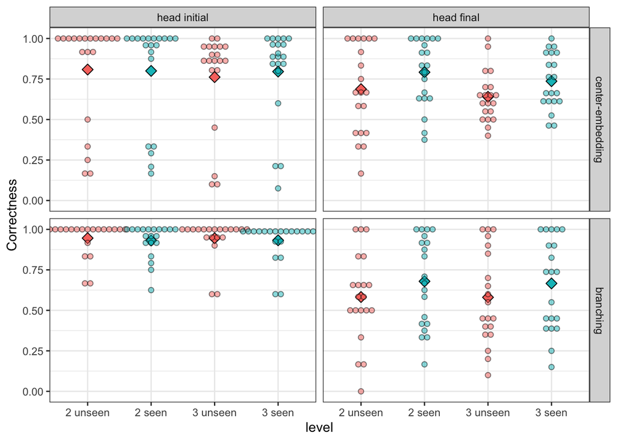

```r
adwmSeenUnseen$level<- factor(adwmSeenUnseen$level)
adwmSeenUnseen12 <- adwmSeenUnseen[adwmSeenUnseen$level %in% c(1,2),]
adwmSeenUnseen12$x <- paste0(adwmSeenUnseen12$level, adwmSeenUnseen12$seenInTraining)
adwmSeenUnseen12$conditionHeadN <- relevel(adwmSeenUnseen12$conditionHeadN, "head initial", "head final")
adwmSeenUnseen12$conditionCE <- relevel(adwmSeenUnseen12$conditionCE, "center-embedding")
ggplot(adwmSeenUnseen12, aes(x= x, y= meanC, fill = seenInTraining)) +
  stat_summary(aes(group=seenInTraining, fill = seenInTraining), fun.y= "mean", geom="point", pch = 23, size = 3)+
  geom_dotplot(binaxis='y',stackdir='center', alpha = .5)+
  facet_grid(conditionCE ~ conditionHeadN)+
  scale_x_discrete(name = "level", labels = c("2 unseen", "2 seen", "3 unseen", "3 seen"))+
  ylab("Correctness")+
  scale_color_manual(labels = c("2","2", "3", "3")) +
  theme_bw()+
  theme(legend.position = "none")
```

```r
contrasts(adwmSeen$level) <- contr.sdif(3)
contrasts(adwmUnSeen$level) <- contr.sdif(3)

contrasts(adwmSeen$conditionCE) <- contr.sum(2)
contrasts(adwmSeen$conditionHeadN) <- contr.sum(2)
contrasts(adwmUnSeen$conditionCE) <- contr.sum(2)
contrasts(adwmUnSeen$conditionHeadN) <- contr.sum(2)
writeLmerNormedAllSeen <- lmer(normedCorrectness ~ level* conditionCE * conditionHeadN + (1 +level|workerId), data = adwmSeen)
summary(writeLmerNormedAllSeen)
```

```
## Linear mixed model fit by REML. t-tests use Satterthwaite's method [
## lmerModLmerTest]
## Formula: normedCorrectness ~ level * conditionCE * conditionHeadN + (1 +
##     level | workerId)
##    Data: adwmSeen
##
## REML criterion at convergence: -403.2
##
## Scaled residuals:
##     Min      1Q  Median      3Q     Max
## -4.4502 -0.0721  0.0618  0.3228  3.6075
##
## Random effects:
##  Groups   Name        Variance Std.Dev. Corr
##  workerId (Intercept) 0.038607 0.19649
##           level2-1    0.031814 0.17836   0.38
##           level3-2    0.005516 0.07427  -0.15 -0.37
##  Residual             0.034262 0.18510
## Number of obs: 1592, groups:  workerId, 80
##
## Fixed effects:
##                                        Estimate Std. Error        df t value
## (Intercept)                            0.829620   0.022505 75.926262  36.863
## level2-1                              -0.105987   0.023630 76.023868  -4.485
## level3-2                              -0.017918   0.013305 76.370318  -1.347
## conditionCE1                           0.007003   0.022505 75.926262   0.311
## conditionHeadN1                       -0.057083   0.022505 75.926262  -2.536
## level2-1:conditionCE1                  0.004378   0.023630 76.023868   0.185
## level3-2:conditionCE1                  0.012253   0.013305 76.370318   0.921
## level2-1:conditionHeadN1              -0.040362   0.023630 76.023868  -1.708
## level3-2:conditionHeadN1              -0.015525   0.013305 76.370318  -1.167
## conditionCE1:conditionHeadN1          -0.048112   0.022505 75.926262  -2.138
## level2-1:conditionCE1:conditionHeadN1 -0.029997   0.023630 76.023868  -1.269
## level3-2:conditionCE1:conditionHeadN1  0.009408   0.013305 76.370318   0.707
##                                       Pr(>|t|)
## (Intercept)                            < 2e-16 ***
## level2-1                              2.54e-05 ***
## level3-2                                0.1820
## conditionCE1                            0.7565
## conditionHeadN1                         0.0133 *
```

[output cut: 20 more lines]

```
## cndtCE1:HN1  0.000  0.000 -0.001  0.000  0.000  0.000    -0.001     0.000
## l2-1:CE1:HN  0.000  0.000  0.000  0.000  0.000  0.000     0.000     0.000
## l3-2:CE1:HN -0.001  0.000 -0.002 -0.001  0.000  0.000    -0.005     0.000
##             l3-2:H cCE1:H l2-1:CE1:
## level2-1
## level3-2
## conditinCE1
## conditnHdN1
## lvl2-1:cCE1
## lvl3-2:cCE1
## lvl2-1:cHN1
## lvl3-2:cHN1
## cndtCE1:HN1  0.000
## l2-1:CE1:HN  0.000  0.281
## l3-2:CE1:HN  0.003 -0.090 -0.366
```

```r
writeLmerNormedAllNoSeen <- lmer(normedCorrectness ~ level* conditionCE * conditionHeadN + (1 +level|workerId), data = adwmUnSeen)
summary(writeLmerNormedAllNoSeen)
```

```
## Linear mixed model fit by REML. t-tests use Satterthwaite's method [
## lmerModLmerTest]
## Formula: normedCorrectness ~ level * conditionCE * conditionHeadN + (1 +
##     level | workerId)
##    Data: adwmUnSeen
##
## REML criterion at convergence: -973.9
##
## Scaled residuals:
##     Min      1Q  Median      3Q     Max
## -3.4489 -0.5106  0.0263  0.3680  3.6121
##
## Random effects:
##  Groups   Name        Variance Std.Dev. Corr
##  workerId (Intercept) 0.046754 0.2162
##           level2-1    0.016338 0.1278   -0.17
##           level3-2    0.005715 0.0756   -0.06 -0.28
##  Residual             0.023423 0.1530
## Number of obs: 1599, groups:  workerId, 80
##
## Fixed effects:
##                                         Estimate Std. Error         df t value
## (Intercept)                            7.342e-01  2.456e-02  7.600e+01  29.887
## level2-1                              -2.421e-02  1.873e-02  7.610e+01  -1.293
## level3-2                              -1.704e-02  1.301e-02  7.620e+01  -1.310
## conditionCE1                           3.059e-02  2.456e-02  7.600e+01   1.245
## conditionHeadN1                       -1.176e-01  2.456e-02  7.600e+01  -4.787
## level2-1:conditionCE1                  2.287e-02  1.873e-02  7.610e+01   1.221
## level3-2:conditionCE1                  2.180e-02  1.301e-02  7.620e+01   1.676
## level2-1:conditionHeadN1              -4.765e-04  1.873e-02  7.610e+01  -0.025
## level3-2:conditionHeadN1               1.145e-02  1.301e-02  7.620e+01   0.880
## conditionCE1:conditionHeadN1          -5.905e-02  2.456e-02  7.600e+01  -2.404
## level2-1:conditionCE1:conditionHeadN1 -5.987e-05  1.873e-02  7.610e+01  -0.003
## level3-2:conditionCE1:conditionHeadN1  5.014e-03  1.301e-02  7.620e+01   0.385
##                                       Pr(>|t|)
## (Intercept)                            < 2e-16 ***
## level2-1                                0.2001
## level3-2                                0.1942
## conditionCE1                            0.2169
## conditionHeadN1                       8.16e-06 ***
```

[output cut: 20 more lines]

```
## cndtCE1:HN1  0.000  0.000  0.000  0.000  0.000  0.000     0.000     0.000
## l2-1:CE1:HN  0.000 -0.001  0.001  0.000  0.000 -0.001     0.001     0.001
## l3-2:CE1:HN  0.000  0.001 -0.002  0.000  0.000  0.001    -0.002    -0.001
##             l3-2:H cCE1:H l2-1:CE1:
## level2-1
## level3-2
## conditinCE1
## conditnHdN1
## lvl2-1:cCE1
## lvl3-2:cCE1
## lvl2-1:cHN1
## lvl3-2:cHN1
## cndtCE1:HN1  0.000
## l2-1:CE1:HN -0.001 -0.131
## l3-2:CE1:HN  0.002 -0.089 -0.442
```

## Coding prepositional meanings

Not all participants interpret the prepositions are they are defined in the compositional language. “Moy” is “to the (viewer’s) left of” and “rae” is “atop,” but some make the opposite interpretations, or are simply not sure. Coding of user interpretations has been done manually.

Prepositions are encoded as follows: A = atop; U = under; E = indef vertical or stacked; N = next to or indef horizontal; R = right of; X = undefined or uninterpretable response.

```r
PH <- c("X", "N", "N", "R", "N", "N", "N", "R", "N", "X",
"N", "N", "N", "N", "N", "X", "N", "N", "N", "N",
"R", "R", "X", "X", "N", "N", "N", "N", "N", "N",
"N", "N", "N", "E", "N", "R", "N", "N", "N", "R",
"X", "N", "X", "N", "N", "N", "N", "N", "X", "X",
"N", "N", "N", "N", "N", "N", "N", "X", "N", "N",
"N", "N", "N", "N", "N", "X", "N", "N", "X", "R",
"N", "N", "N", "N", "X", "N", "X", "N", "N", "U")

PV <- c("X", "A", "E", "U", "A", "E", "E", "U", "A", "X",
"E", "E", "A", "A", "A", "X", "A", "A", "A", "E",
"U", "U", "X", "X", "E", "A", "A", "E", "E", "E",
"A", "E", "E", "N", "A", "U", "E", "A", "E", "U",
"X", "E", "X", "U", "E", "U", "U", "E", "X", "X",
"A", "A", "A", "E", "E", "A", "A", "X", "A", "A",
"A", "A", "U", "E", "E", "X", "E", "A", "X", "A",
"A", "A", "A", "U", "X", "E", "X", "A", "A", "N")
prepList <- cbind(prepList, PH, PV)
prepHorizGloss <-c()
prepVertGloss <- c()
for (w in prepList$workerId) {
  writeCount = nrow(allDataWriteMerged[allDataWriteMerged$workerId == w,])
  prepHorizGloss <- c(prepHorizGloss, rep(as.character(prepList$PH[prepList$workerId== w]), each = writeCount))
  prepVertGloss <- c(prepVertGloss, rep(as.character(prepList$PV[prepList$workerId== w]), each = writeCount))
}
allDataWriteMerged <- cbind(allDataWriteMerged, prepHorizGloss, prepVertGloss)
```

## Creating write-in file

Saving initials of given nouns for further analysis. Nouns will be used to create strings in all possible grammars that users may be using (in the python program described below), to which their corrected, abbreviated input can be compared.

```r
consonants <- c()
for (n in 1:nrow(allDataWriteMerged)) {
consonants <- c(consonants, paste0(sapply(strsplit(as.character(allDataWriteMerged$correctLexicon[n]), " "), function(x) {substring(x, 1,1)})[0:4], collapse = ""))}
allDataWriteMerged <- cbind(allDataWriteMerged, consonants)

write.csv(allDataWriteMerged,paste0(getwd(), '/allDataWritePilotLrn1.csv'))
```

The resulting CSV is then fed through the python file “array to caption syntax orders”

Output models to HTML

```r
library(sjPlot)
a<- as.data.frame(coefficients(summary(testLmerInteract)))
rownames(a) <-gsub("Intercept", "level 1/branching/head-initial", rownames(a))
rownames(a) <-gsub("as.numeric\\(level - 1\\)", "level 3", rownames(a))
rownames(a) <-gsub("conditionCE1", "center-embedded", rownames(a))
rownames(a) <-gsub("conditionHeadN1", "head-final", rownames(a))
rownames(a) <-gsub(":", "/", rownames(a))

b<- as.data.frame(coefficients(summary(writeLmerNormed)))
rownames(b) <-gsub("Intercept", "level 1/branching/head-initial", rownames(b))
rownames(b) <-gsub("as.numeric\\(level - 1\\)", "level", rownames(b))
rownames(b) <-gsub("conditionCE1", "center-embedding", rownames(b))
rownames(b) <-gsub("conditionHeadN1", "head-final", rownames(b))
rownames(b) <-gsub(":", "/", rownames(b))

c<- as.data.frame(coefficients(summary(writeLmerNormedSeen)))
rownames(c) <-gsub("Intercept", "level 2/branching/head-initial/unseen", rownames(c))
rownames(c) <-gsub("level", "level 3", rownames(c))
rownames(c) <-gsub("conditionCE1", "center-embedding", rownames(c))
rownames(c) <-gsub("conditionHeadN1", "head-final", rownames(c))
rownames(c) <-gsub("seenInTraining1", "unseen", rownames(c))
rownames(c) <-gsub(":", "/", rownames(c))

d<- as.data.frame(coefficients(summary(writeLmerNormedAllSeen)))
rownames(d) <-gsub("Intercept", "level 1/branching/head-initial", rownames(d))
rownames(d) <-gsub("as.numeric\\(level - 1\\)", "level", rownames(d))
rownames(d) <-gsub("conditionCE1", "center-embedding", rownames(d))
rownames(d) <-gsub("conditionHeadN1", "head-final", rownames(d))
rownames(d) <-gsub(":", "/", rownames(d))

e<- as.data.frame(coefficients(summary(writeLmerNormedAllNoSeen)))
rownames(e) <-gsub("Intercept", "level 2/branching/head-initial", rownames(e))
rownames(e) <-gsub("as.numeric\\(level - 1\\)", "level", rownames(e))
rownames(e) <-gsub("conditionCE1", "center-embedding", rownames(e))
rownames(e) <-gsub("conditionHeadN1", "head-final", rownames(e))
rownames(e) <-gsub(":", "/", rownames(e))
rownames(e) <-gsub("3-2", "4-3", rownames(e))
rownames(e) <-gsub("2-1", "3-2", rownames(e))

library(sjmisc)
allModels <- list(a, b,c, d, e)
for (i in 1:length(allModels)) {
  allModels[[i]] <- round_num(allModels[[i]], 3)
allModels[[i]][,ncol(allModels[[i]])][allModels[[i]][,ncol(allModels[[i]])] == 0] <- "< .001"
}
tab_dfs(allModels, titles = c("Comprehension task", "Production task", "Seen vs. unseen arrays", "Production task: seen only", "Production task: novel only"), file = paste0(getwd(), '/tables.html'))
```

Comprehension task

| Estimate | Std. Error | z value | Pr(>\|z\|) |
| --- | --- | --- | --- |
| 2.41 | 0.20 | 12.02 | < .001 |
| 0.53 | 0.32 | 1.67 | 0.095 |
| 0.18 | 0.30 | 0.59 | 0.552 |
| 0.01 | 0.18 | 0.06 | 0.955 |
| -0.39 | 0.18 | -2.12 | 0.034 |
| 0.07 | 0.24 | 0.30 | 0.76 |
| 0.29 | 0.20 | 1.42 | 0.155 |
| -0.23 | 0.24 | -0.98 | 0.327 |
| -0.30 | 0.21 | -1.46 | 0.144 |
| -0.16 | 0.18 | -0.87 | 0.383 |
| 0.14 | 0.24 | 0.61 | 0.54 |
| -0.33 | 0.20 | -1.65 | 0.099 |

Production task

| Estimate | Std. Error | df | t value | Pr(>\|t\|) |
| --- | --- | --- | --- | --- |
| 0.81 | 0.02 | 76.00 | 35.80 | < .001 |
| -0.05 | 0.01 | 76.00 | -7.82 | < .001 |
| 0.01 | 0.02 | 76.00 | 0.36 | 0.718 |
| -0.07 | 0.02 | 76.00 | -3.17 | 0.002 |
| 0.02 | 0.01 | 76.00 | 3.04 | 0.003 |
| -0.02 | 0.01 | 76.00 | -3.34 | 0.001 |
| -0.05 | 0.02 | 76.00 | -2.29 | 0.025 |
| -0.00 | 0.01 | 76.00 | -0.50 | 0.617 |

Seen vs. unseen arrays

| Estimate | Std. Error | df | t value | Pr(>\|t\|) |
| --- | --- | --- | --- | --- |
| 0.80 | 0.03 | 79.05 | 24.12 | < .001 |
| -0.02 | 0.01 | 84.98 | -1.67 | 0.099 |
| -0.01 | 0.03 | 79.05 | -0.33 | 0.742 |
| -0.09 | 0.03 | 79.05 | -2.56 | 0.012 |
| -0.02 | 0.01 | 1746.51 | -1.38 | 0.166 |
| 0.02 | 0.01 | 84.98 | 1.37 | 0.174 |
| -0.01 | 0.01 | 84.98 | -0.66 | 0.513 |
| -0.07 | 0.03 | 79.05 | -1.98 | 0.052 |
| -0.00 | 0.01 | 1746.78 | -0.36 | 0.716 |
| -0.00 | 0.01 | 1746.51 | -0.28 | 0.781 |
| -0.04 | 0.01 | 1746.51 | -2.60 | 0.009 |
| 0.01 | 0.01 | 84.98 | 0.37 | 0.713 |
| 0.01 | 0.01 | 1746.78 | 0.64 | 0.525 |
| 0.01 | 0.01 | 1746.78 | 0.90 | 0.37 |
| 0.01 | 0.01 | 1746.51 | 0.35 | 0.726 |
| -0.01 | 0.01 | 1746.78 | -0.54 | 0.591 |

Production task: seen only

| Estimate | Std. Error | df | t value | Pr(>\|t\|) |
| --- | --- | --- | --- | --- |
| 0.83 | 0.02 | 75.93 | 36.86 | < .001 |
| -0.11 | 0.02 | 76.02 | -4.49 | < .001 |
| -0.02 | 0.01 | 76.37 | -1.35 | 0.182 |
| 0.01 | 0.02 | 75.93 | 0.31 | 0.757 |
| -0.06 | 0.02 | 75.93 | -2.54 | 0.013 |
| 0.00 | 0.02 | 76.02 | 0.18 | 0.854 |
| 0.01 | 0.01 | 76.37 | 0.92 | 0.36 |
| -0.04 | 0.02 | 76.02 | -1.71 | 0.092 |
| -0.02 | 0.01 | 76.37 | -1.17 | 0.247 |
| -0.05 | 0.02 | 75.93 | -2.14 | 0.036 |
| -0.03 | 0.02 | 76.02 | -1.27 | 0.208 |
| 0.01 | 0.01 | 76.37 | 0.71 | 0.482 |

Production task: novel only

| Estimate | Std. Error | df | t value | Pr(>\|t\|) |
| --- | --- | --- | --- | --- |
| 0.73 | 0.03 | 76.00 | 29.89 | < .001 |
| -0.02 | 0.02 | 76.10 | -1.29 | 0.2 |
| -0.02 | 0.01 | 76.20 | -1.31 | 0.194 |
| 0.03 | 0.03 | 76.00 | 1.25 | 0.217 |
| -0.12 | 0.03 | 76.00 | -4.79 | < .001 |
| 0.02 | 0.02 | 76.10 | 1.22 | 0.226 |
| 0.02 | 0.01 | 76.20 | 1.68 | 0.098 |
| -0.00 | 0.02 | 76.10 | -0.03 | 0.98 |
| 0.01 | 0.01 | 76.20 | 0.88 | 0.382 |
| -0.06 | 0.03 | 76.00 | -2.40 | 0.019 |
| -0.00 | 0.02 | 76.10 | -0.00 | 0.997 |
| 0.01 | 0.01 | 76.20 | 0.39 | 0.701 |